# ds202_lab3_team

Jessie Bustin Github: jebustin & Syed Hasan @github shasan2519

2/19/2020

```r
GSS = rename(df, "Year"='Gss year for this respondent',
             "Pol_Affl"="Political party affiliation",
             "Race"="Race of respondent",
             "Sex"="Respondents sex",
             "respondentSpouse_TopEdu"="Spouses highest degree",
             "Respondent_TopEdu"="Rs highest degree",
             "YearHSCompleted"="Highest year of school completed",
             "NumOfChildren"="Number of children",
             "WidowStatus"="Ever been widowed",
             "MaritalStatus"="Marital status",
             "HoursWorked"="Number of hours usually work a week",
             "ID"="Respondent id number",
             "HappyIndex"="General happiness")
GSS<-na.omit(GSS)
GSS<-GSS[!(GSS$Pol_Affl=="No answer" | GSS$respondentSpouse_TopEdu=="No answer" | GSS$respondentSpouse_TopEdu=="Don't know" | GSS$Respondent_TopEdu=="No answer" | GSS$YearHSCompleted=="No answer"  | GSS$NumOfChildren=="Dk na" | GSS$WidowStatus=="No answer" | GSS$WidowStatus=="Don't know" | GSS$MaritalStatus=="No answer" | GSS$HoursWorked=="No answer" | GSS$HoursWorked=="Don't know" | GSS$HappyIndex=="No answer" | GSS$HappyIndex=="Not applicable"),]
GSS = transform(GSS, YearHSCompleted = as.numeric(YearHSCompleted))
```

## 1

How does the happiness of a respondent relate to the marriage status?

The bar plot below shows that people are genrally more happy while they’re married. So are people who’ve never married. A larger portion of people are not very happy when they are seperated and the smallest portion of not very happy respondents are married.

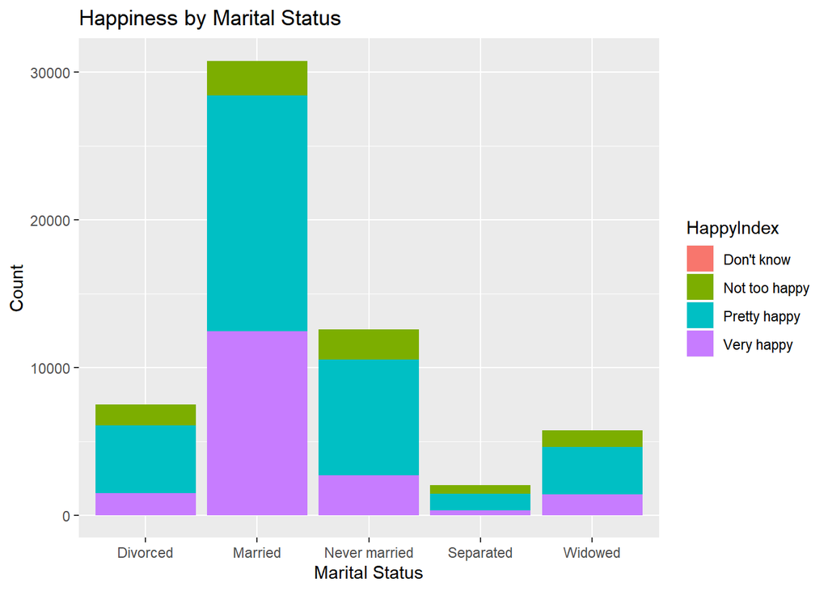

```r
Q1<-GSS %>%
  select(MaritalStatus, HappyIndex)

ggplot(data = Q1, aes(x = MaritalStatus, fill = HappyIndex)) +
  geom_bar() +
  ggtitle("Happiness by Marital Status") +
  xlab("Marital Status") +
  ylab("Count")
```

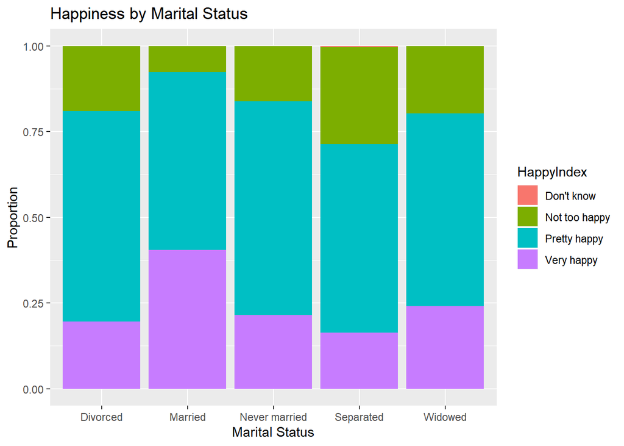

```r
ggplot(data = Q1, aes(x = MaritalStatus, fill = HappyIndex)) +
  geom_bar(position = "fill") +
  ggtitle("Happiness by Marital Status") +
  xlab("Marital Status") +
  ylab("Proportion")
```

## 2

Does the sex of the respondent affect the relationship you found in Q1?

The graph below shows that happiness level proportions accross all categories of marital status is roughly the same between the sexes. This means that the influence of marital status on happiness is the same for men and women.

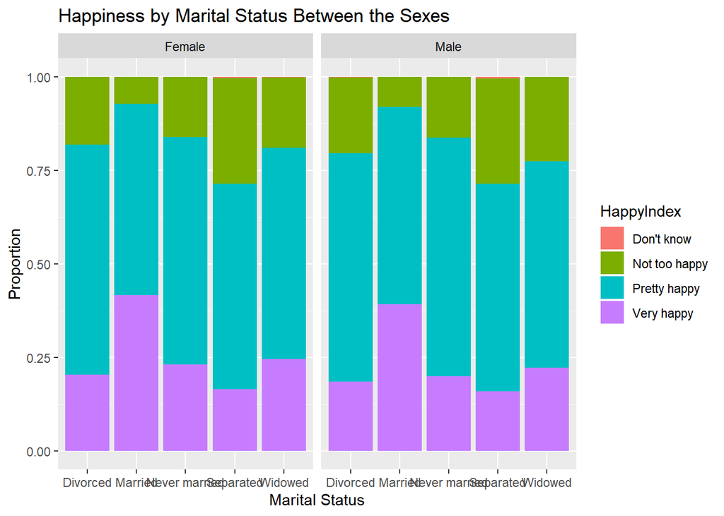

```r
Q2<-GSS %>%
  select(MaritalStatus, HappyIndex, Sex)

ggplot(data = Q2, aes(x = MaritalStatus, fill = HappyIndex)) +
  geom_bar(position = "fill") +
  facet_wrap(~Sex) +
  ggtitle("Happiness by Marital Status Between the Sexes") +
  xlab("Marital Status") +
  ylab("Proportion")
```

## 3

How does the happiness of a respondent relate to the political party affiliation?

Strong republicans are more likely to be very happy than the other party affiliations. They are also less likely to be not very happy. For all party affiliations it is most likely that the respondent is pretty happy, and least likely to be not too happy. Whether the small differences in proportions of the happiness levels between the parties are significant would require further modeling and hypothesis testing.

It was decided that the happiness levels would not be converted to numeric options because that would impose value judgements on the differences between the happiness levels. Is the difference between not too happy and pretty happy the same as from pretty happy to very happy? Numerical coding for this categorical variable is possible but any numerical analysis on the coding would be unjust.

```r
GSS$Pol_Affl <- factor(GSS$Pol_Affl, levels = c("Strong democrat",
    "Not str democrat", "Ind,near dem", "Strong republican", "Not st
    republican", "Ind,near rep", "Independent", "Other party", "Don't
    know"))

counts <- GSS %>% group_by(HappyIndex, Pol_Affl) %>%
          summarise(counts = n())
```

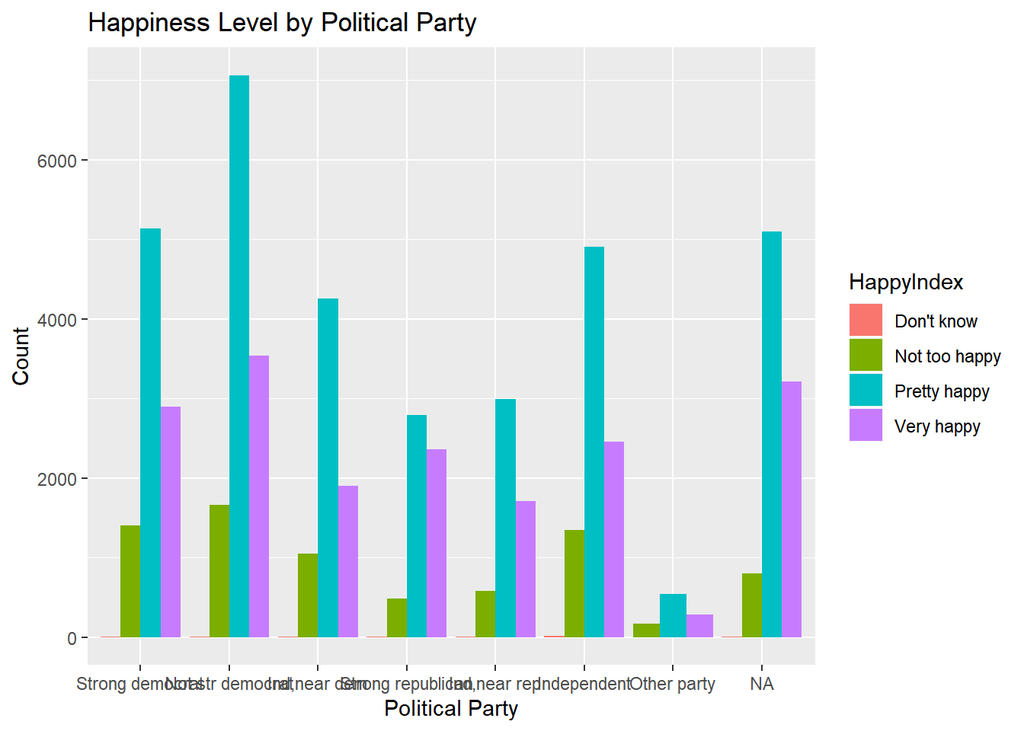

```r
ggplot(data = counts, aes(x = Pol_Affl, y = counts,
                          fill = HappyIndex)) +
  geom_bar(stat = "identity", position = position_dodge()) +
  ggtitle("Happiness Level by Political Party") +
  xlab("Political Party") +
  ylab("Count")
```

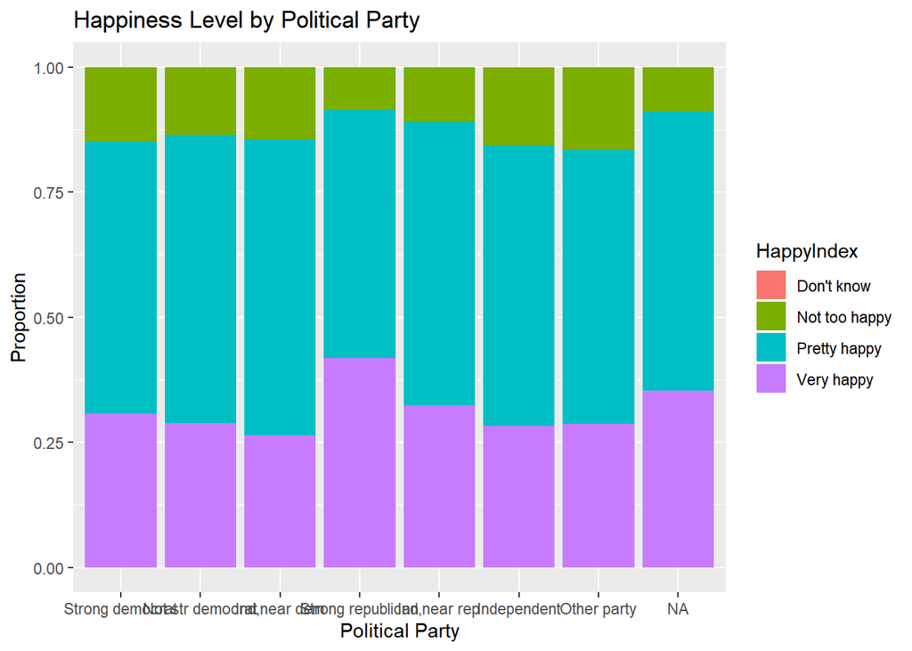

```r
ggplot(data = GSS, aes(x = Pol_Affl, fill = HappyIndex)) +
  geom_bar(position = "fill") +
  ggtitle("Happiness Level by Political Party") +
  xlab("Political Party") + ylab("Proportion")
```

## 4

Raise four questions that can be answered by the GSS dataset. Extract appropriate data from the website, explore, and answer the questions.

1. Does the number of children the respondent have vary with race? How about by race and over time?

It does appear that it is more likely for blacks to have more children overall. Year in and year out this tends to vary a little though. Whether this is a normal level of variance within the sample from year to year is something to be ascertained with further analysis. Using regression, it would be interesting to find out if race and year are significant factors in predicting the number of chlidren. While looking at the data by year, it is interesting to see which time periods see an increase in respondents with 0 children accross the races such as recently or the early 80’s. Perhaps economic and social instability influence these changes.

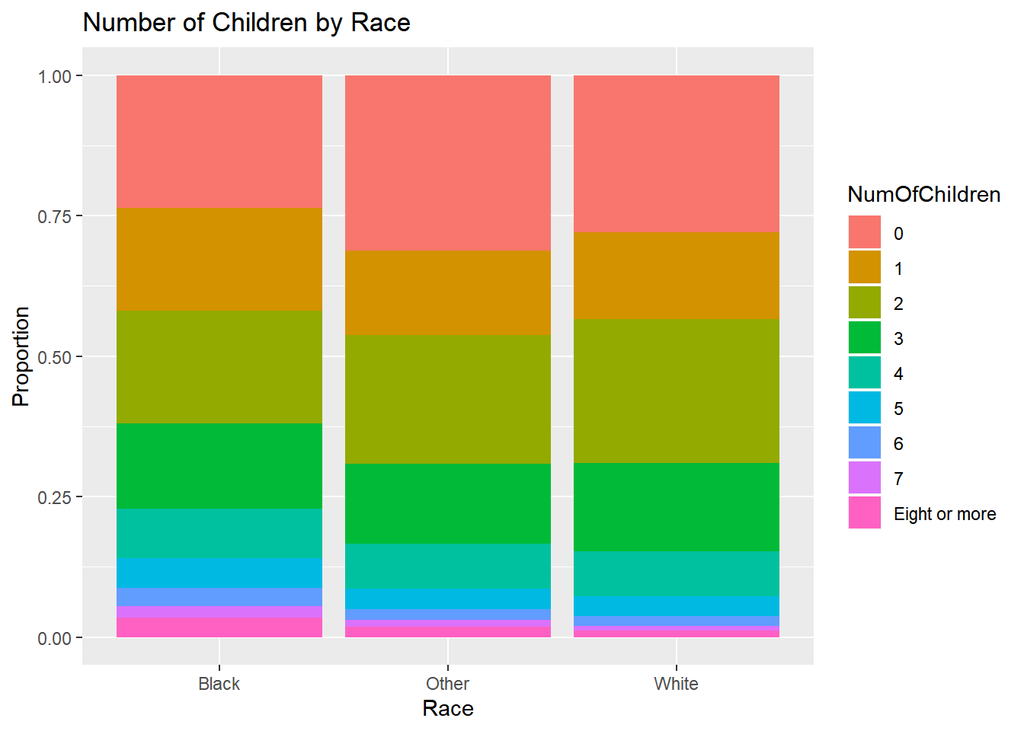

```r
ggplot(data = GSS, aes(x = Race, fill = NumOfChildren)) +
  geom_bar(position = "fill") +
  ggtitle("Number of Children by Race") +
  xlab("Race") +
  ylab("Proportion")
```

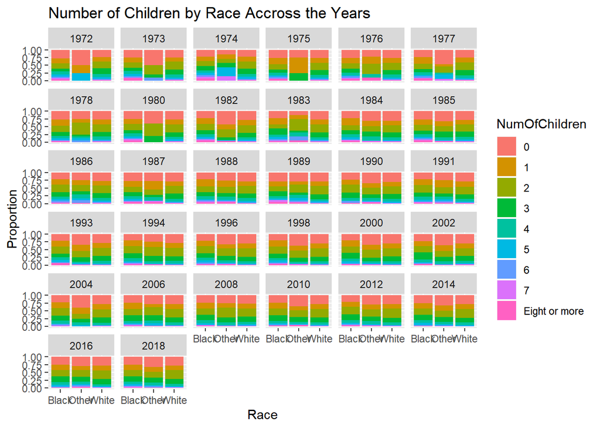

```r
ggplot(data = GSS, aes(x = Race, fill = NumOfChildren)) +
  geom_bar(position = "fill") +
  facet_wrap(~Year) +
  ggtitle("Number of Children by Race Accross the Years") +
  xlab("Race") +
  ylab("Proportion")
```

2. Does the respondent’s spouse’s highest degree affect the years of school the respondent completed? Does this relationship change for for men and women?

As the highest degree that a spouse recieved increases, the mean number of years of school completed by the respondent also increases. The spread of these means changes between females and males as well. For example, if a spouse has not received a high school degree then for males the average number of years of school completed is lower than for females. The inverse is then true on the other end where the spouse has a graduate degree, translating to a higher mean number of years of education for males than females.

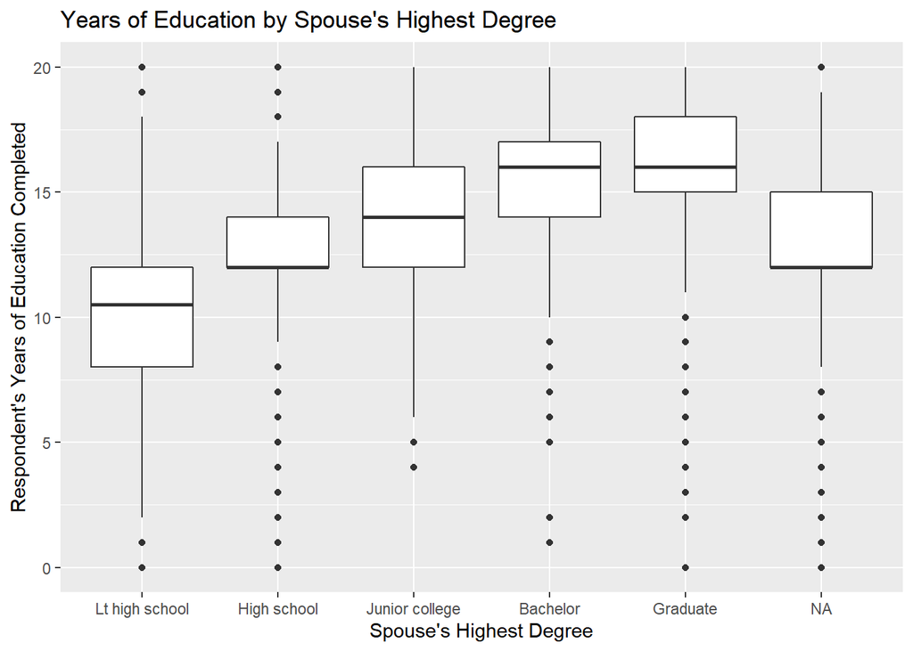

```r
GSS$respondentSpouse_TopEdu <- factor(GSS$respondentSpouse_TopEdu,
    levels = c("Lt high school", "High school", "Junior college",
               "Bachelor", "Graduate", "Not Applicable"))

ggplot(GSS, aes(x = respondentSpouse_TopEdu, y = YearHSCompleted)) +
  geom_boxplot() +
  ggtitle("Years of Education by Spouse's Highest Degree") +
  xlab("Spouse's Highest Degree") +
  ylab("Respondent's Years of Education Completed")
```

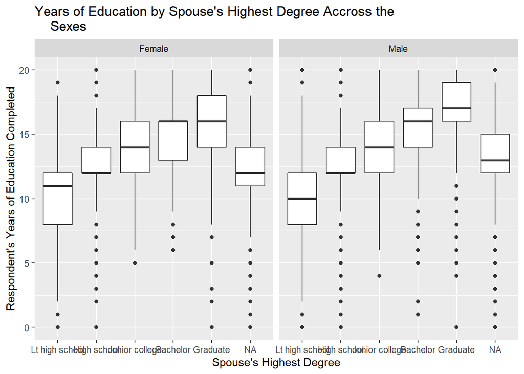

```r
ggplot(GSS, aes(x = respondentSpouse_TopEdu, y = YearHSCompleted)) +
  facet_wrap(~Sex) +
  geom_boxplot() +
  ggtitle("Years of Education by Spouse's Highest Degree Accross the
    Sexes") +
  xlab("Spouse's Highest Degree") +
  ylab("Respondent's Years of Education Completed")
```

3. Does the distribution between political parties change based on the highest degree of the respondent? Does this relationship change between races?

Yes, it definitly does! People become more decisive as their highest degree increases as they are less likely to be independent. People that did not finish high school and those with graduate degrees also are more likely to be liberal than those with a high school, jr college, or bachelors degree. Those with only a bachelors degree are more likely to be conservative over the other degree levels. This variability does change between the races. First off, blacks are overall much more likely to be a strong democrat than whites or other. Also though, this doesn’t change with the education level for blacks while it does for whites and those in the other category. Accross the races it holds true that the chance of being an independent goes down as the highest degree level goes up.

While looking at these it was also interesting to see the mosiac plot. While this plot is a little more difficult to read I think it is a good reminder of what proportion of the study has each highest degree level. Predominitly the highest degree level is high school.

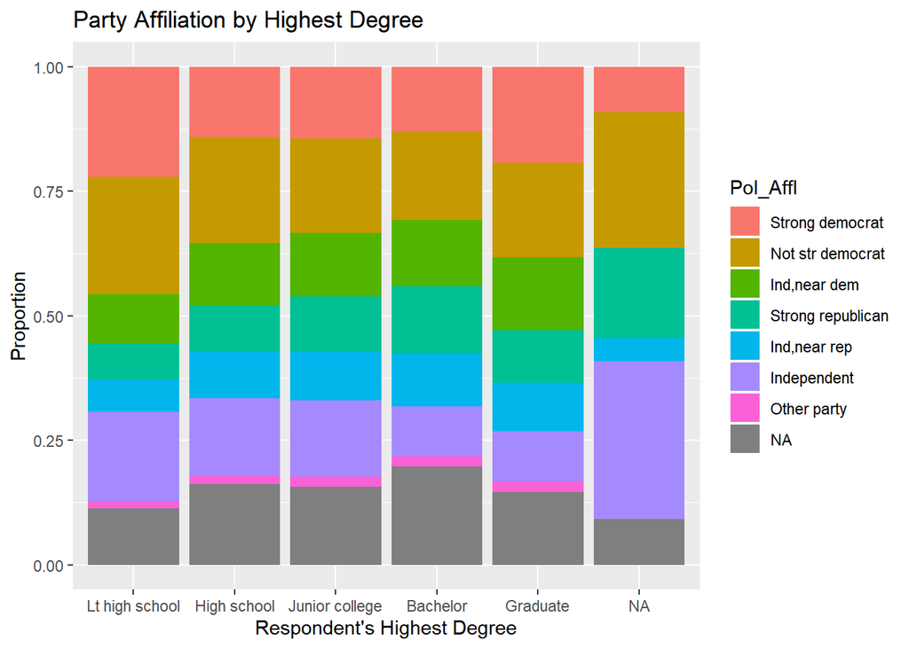

```r
GSS$Respondent_TopEdu <- factor(GSS$Respondent_TopEdu,
    levels = c("Lt high school", "High school", "Junior college",
               "Bachelor", "Graduate", "Not Applicable"))

ggplot(data = GSS, aes(x = Respondent_TopEdu, fill = Pol_Affl)) +
  geom_bar(position = "fill") +
  ggtitle("Party Affiliation by Highest Degree") +
  xlab("Respondent's Highest Degree") +
  ylab("Proportion")
```

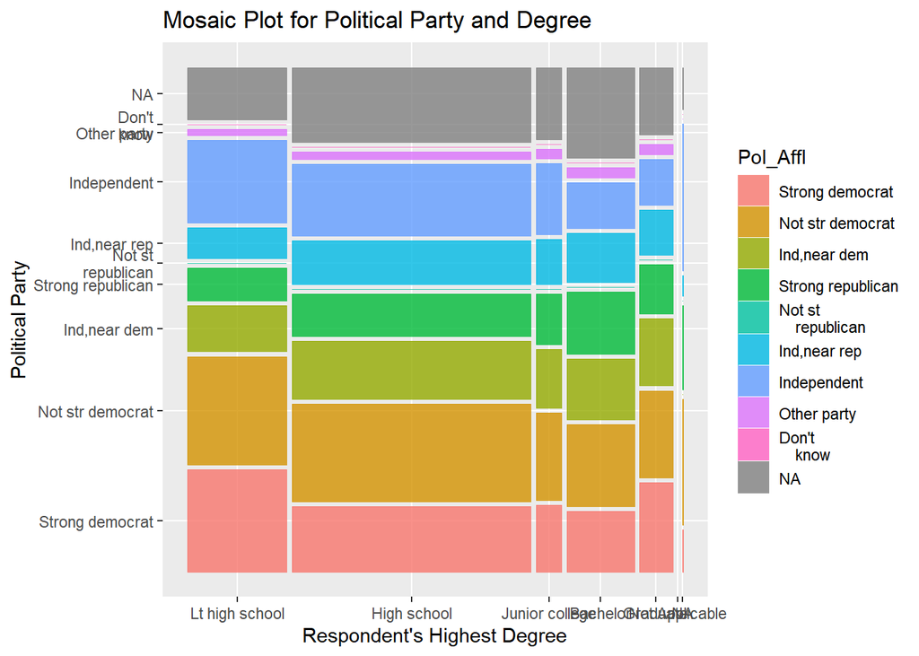

```r
ggplot(data = GSS) + geom_mosaic(aes(x = product(Pol_Affl,
  Respondent_TopEdu), fill = Pol_Affl), na.rm=FALSE) +
  ggtitle("Mosaic Plot for Political Party and Degree") +
  xlab("Respondent's Highest Degree") + ylab("Political Party")
```

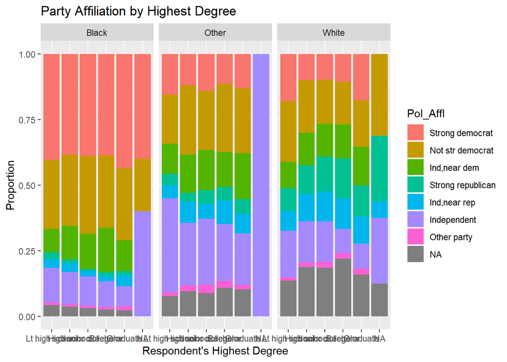

```r
ggplot(data = GSS, aes(x = Respondent_TopEdu, fill = Pol_Affl)) +
  geom_bar(position = "fill") +
  facet_wrap(~Race) +
  ggtitle("Party Affiliation by Highest Degree") +
  xlab("Respondent's Highest Degree") +
  ylab("Proportion")
```

4. Is there a relationship between happiness and number of children? Does this conclusion hold true for both men and women?

It appears that the number of children does correlate to a change in the respondents level of happiness. It appears that as the number of children increases the extreme positions become more likely, either “very happy” or “not too happy.” This overall trend varies a little between the sexes. AS women have more children then they are less likely to be very happy and more likely to be not too happy. Men on the other hand appear to be more likely to be very happy as they have more children. Whether these small differences are statistically significant should be further investigated before any conclusions are drawn though.

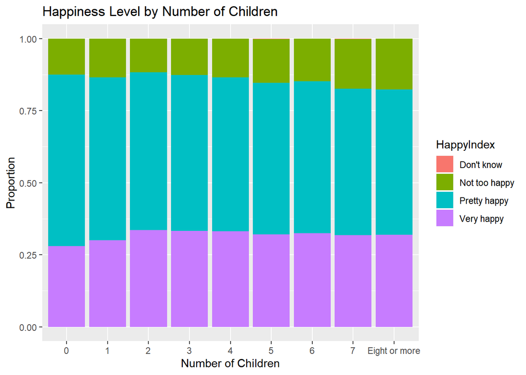

```r
ggplot(data = GSS, aes(x = NumOfChildren, fill = HappyIndex)) +
  geom_bar(position = "fill") +
  ggtitle("Happiness Level by Number of Children") +
  xlab("Number of Children") +
  ylab("Proportion")
```

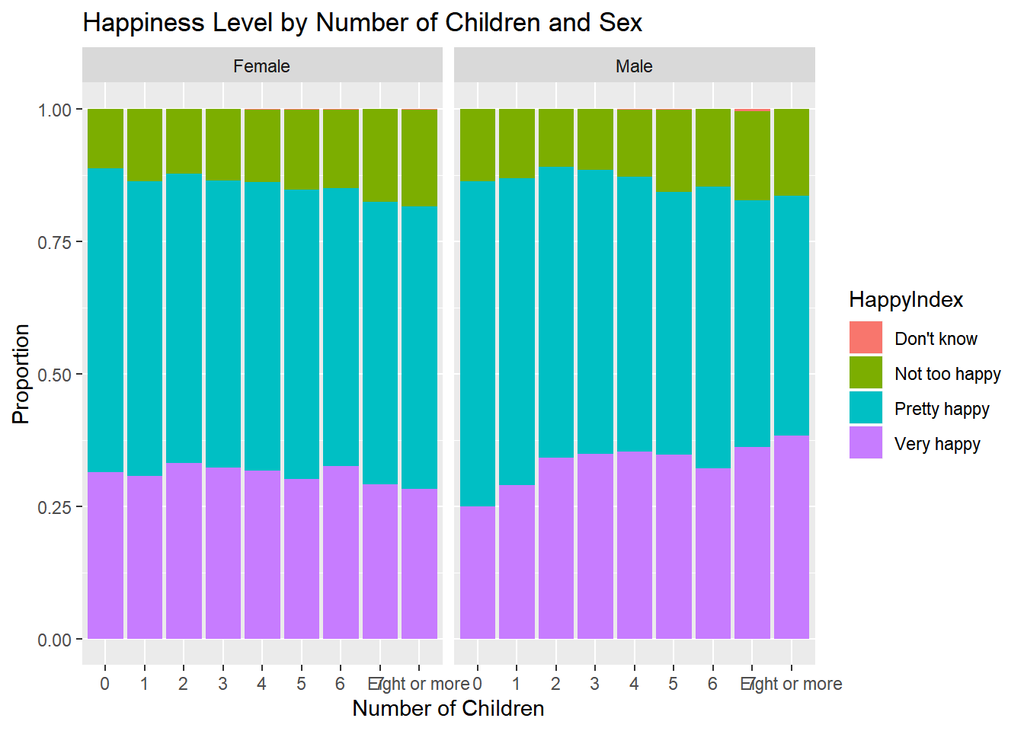

```r
ggplot(data = GSS, aes(x = NumOfChildren, fill = HappyIndex)) +
  facet_wrap(~Sex) +
  geom_bar(position = "fill") +
  ggtitle("Happiness Level by Number of Children and Sex") +
  xlab("Number of Children") +
  ylab("Proportion")
```